# Internet Redlining

Neha, Aidan, and David

11/13/2022

library(knitr)

## Overview

- Please see Canvas for more details.

## Data_summary_in_nation

Here is the mean data of AT&T group by state.

```
## # A tibble: 20 × 7
##    state location                        faste…¹ faste…² race_…³ ppl_p…⁴ media…⁵
##    <chr> <chr>                             <dbl>   <dbl>   <dbl>   <dbl>   <dbl>
##  1 AL    Huntsville city, huntsville, AL   2675.   107.    0.405    828.  63650.
##  2 AR    Little Rock city, little rock,…   1686.    92.2   0.514   1086.  65856.
##  3 CA    Los Angeles city, los angeles,…    582.    54.4   0.734   8252.  69185.
##  4 FL    Jacksonville city, jacksonvill…   1416.    81.2   0.472   1135.  62096.
##  5 GA    Atlanta city, atlanta, GA         2260.   102.    0.617   2010.  75289.
##  6 IL    Chicago city, chicago, IL          390.    46.9   0.667   8001.  64104.
##  7 IN    Indianapolis city (balance), i…   1358.    82.7   0.478   1705.  47519.
##  8 KS    Wichita city, wichita, KS         1633.    87.8   0.359   1293.  62105.
##  9 KY    Louisville city, louisville, KY   1742.    93.6   0.410   2262.  47823.
## 10 LA    New Orleans city, new orleans,…    774.    47.1   0.660   3022.  51862.
## 11 MI    Detroit city, detroit, MI          251.    50.4   0.904   2574.  34732.
## 12 MO    Kansas City city, kansas city,…    275.    52.3   0.454   1439.  62957.
## 13 MS    Jackson city, jackson, MS          517.    58.3   0.837   1196.  45736.
## 14 NC    Charlotte city, charlotte, NC     2068.    95.8   0.562   1359.  75860.
## 15 OH    Columbus city, columbus, OH        706.    67.5   0.444   2465.  56422.
## 16 OK    Oklahoma City city, oklahoma c…   1522.    84.1   0.487     NA   58531.
## 17 SC    Charleston city, charleston, SC   1025.    70.2   0.285   1281.  77062.
## 18 TN    Nashville-Davidson metropolita…   2846.   120.    0.427   1350.  66359.
## 19 TX    Houston city, houston, TX         1109.    77.4   0.742   2600.  68205.
## 20 WI    Milwaukee city, milwaukee, WI     1449.    83.9   0.640   3920.  44598.
## # … with abbreviated variable names ¹fastest_speed_down, ²fastest_speed_price,
## #   ³race_perc_non_white, ⁴ppl_per_sq_mile, ⁵median_household_income
```

## Type of internet most often used

This pie chart shows the distributions of the different kinds of internet most used: Copper, Fiber, Fiber Based, Not Fiber.

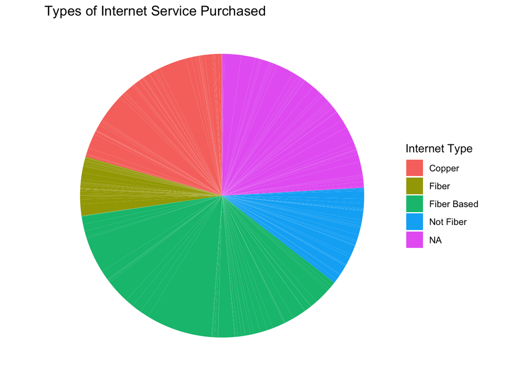

This chart shows the distribution of the types of internet used across America. In the future, we will have this data be able to be segmented by state, so users can choose a state that they want to inspect.

## Internet speed for each provider

Here’s a barchart showing the up and download speed:

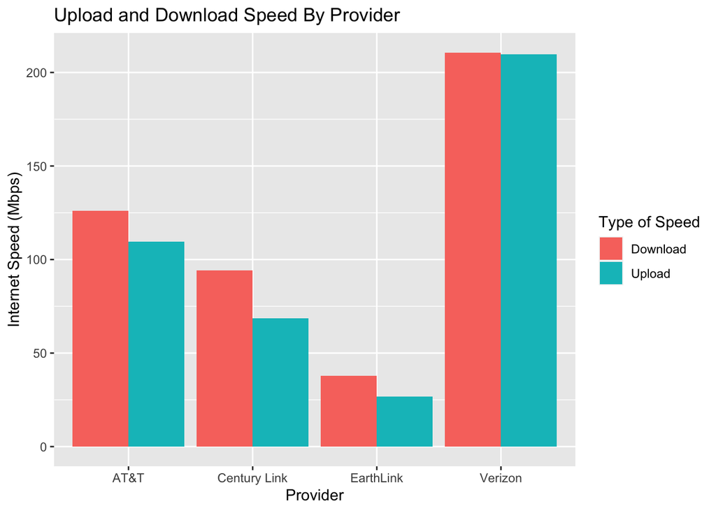

This chart is a bar chart that, based on who the provider is, shows the average upload and download speed across all the data we have. This chart is also interactive, when you hover over each column, you can see the exact upload and download speed. This chart allows users to see which Internet Service Providers (ISPs) have the fastest average internet.

## Internet speed distributions based on redlining

To visually identify disparities in internet speeds by redlining level, here is a choropleth math that visualizes the percentage point difference of lower income areas with slower internet speeds:

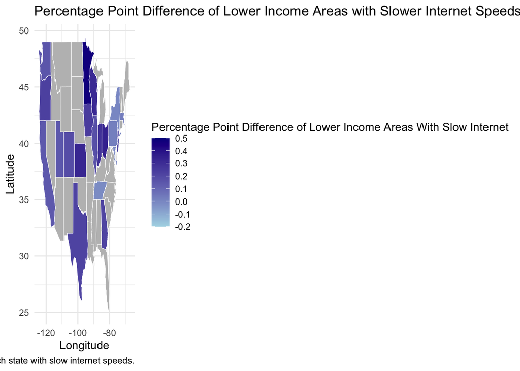

This data visualization includes a choropleth map that displays the percentage point difference of lower income areas across the country with slower internet speeds. This chart allows users to visualize the overall impacts of internet redlining across the country through a scale of redlining grades represented by varying shades of blue. A lighter shade of blue represents less internet redlining, whereas a darker shade represents a higher level of internet redlining and grey represents areas where the data was “NA”.